# Big Data Homework - 4

Błażej Wiórek

5/24/2020

### Stein phenomenon

Let’s assume that: $Y \sim N(\mu, \sigma^2I)$ and $y$ represents single observation from such distribution. We are interested in estimating $\mu$. Maximum Likelihood Estimator (MLE) for $\mu$ is sample mean. In presented case we have a single vector, hence MLE is: $\hat{\mu}_{MLE}=y$. it turns out that there are better estimators in terms of mean squared error $\mathbb{E}[||\mu - \hat{\mu}||^2]$. This result is known as Stein phenomenon.

The estimator that was announced is called James-Stein estimator and it is given by:

$$\hat{\mu}_{JS} = (1 - \frac{\sigma^2(p-2)}{||X||^2})X \text{ ,where } p>2$$

Since $(p-2)\sigma^2 <||y||^2$, it’s immediate that presented estimator shrinks $\hat{\mu}_{MLE}$ towards zero. This idea can be generalized to shrinkage towards any arbitrary vector $v$.

$$\hat{\mu} = (1 - \frac{\sigma^2(p-3)}{||y - v||^2})(y - v) + v \text{ ,where } p>3$$
The important property of both estimators is if $p > 3$ then for both JS estimators we have that: $\mathbb{E}||\hat{\mu} - \mu||^2 < \mathbb{E}||\hat{\mu}_{MLE} - \mu||^2$.

### Estimating via multiple testing procedures

Estimation base on multiple testing is based on the idea of separating noise from true signals. If signal $\mu_i$ is strong then it should be taken under consideration in estimation process, otherwise it is considered as noise and can be neglected. Such construction should perfmorm well when vector $\mu$ is sparse.
$$\hat{\mu_i} = \begin{cases} X_i & \mbox{if } H_{0,i} \text{ is rejected} \\ 0 & \mbox{if } H_{0,i} \text{ is not rejected} \end{cases}$$

## Assignment 1

Simulate 500 realizations of the random vector $X = (X_1, ..., X_p) \sim N(\mu, I)$ where $p = 500$

- $\mu = 0$
- $\mu$ is obtained by a simulation (just once) from $N(0, 5I)$
- $\mu_1,... ,\mu_p$ are obtained as iid from $N(20, 5)$ (just once).

For each of these cases compare the mean square error of the maximum likelihood estimate X, classical James-Stein estimate $\hat{\mu}_{JS}=(1-\frac{p-2}{||X||^2})X$ and the Empirical Bayes estimate $\mu_i^{EB}=\bar{X} + (1 - \frac{p-3}{S})(X_i - \bar{X})$, where $S=\sum^p_{i=1}(X_i - \bar{X})^2$.

It’s not difficult to see that $\hat{\mu}_{JS}$ refers to estimator that shrinks towards zero and $\mu_i^{EB}$ shrinks towards mean.

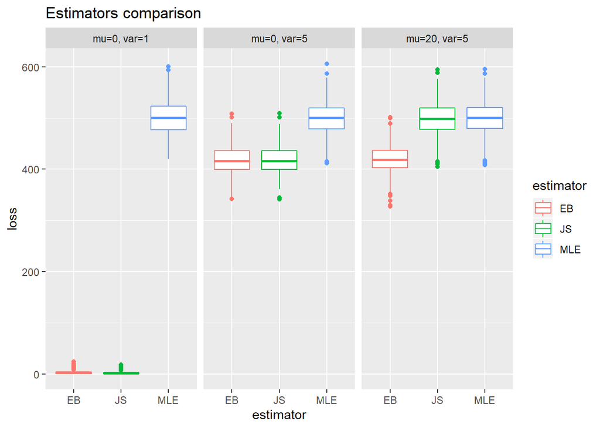

Estimators performance summary:

```
##     mu=0, var=1 mu=0, var=5 mu=20, var=5
## EB        3.059     417.210      420.155
## JS        2.186     417.202      498.587
## MLE     501.189     500.049      499.795
```

In presented experiment both James-Stein and Empirical Bayes estimators clearly outperform MLE estimator. The risk of MLE is almost constant which is expected behavior because $R(\hat{\mu}_{MLE}, \mu) = \mathbb{E}||X-\mu||^2_2=p\sigma^2=500$. In the third case James-Stein estimator is almost as biased as MLE. This is due the following fact:

$$\mathbb{E}||\hat{\mu}_{JS} - \mu||2 \leq p - \frac{p-2}{1 + \frac{||\mu||^2}{p-2}}$$

Hence the expected loss grows to $p$ as $||\mu^2||$ grows. Upper boundary for expected loss in above experiments can be summarized as follows:

```
##                  Experiment_1 Experiment_2 Experiment_3
## Expected loss JS            2     417.0136     498.7776
```

## Assignment 2

Simulate $500$ realizations of the random vector $X=(X_1, ..., X_p) \sim N(\mu, \Sigma)$ where $p=500$ and the vector $\mu$ is as in Problem 1. Compare the mean square error of the maximum likelihood estimate X with the extension of James-Stein estimate by Mary Ellen Bock (1975).

$$\mu_{MEB} = (1 - \frac{\bar{p}-2}{X^T\Sigma^{-1}X})X \text{, where } \hat{p} = \frac{Tr(\Sigma)}{\lambda_{max}(\Sigma)}$$

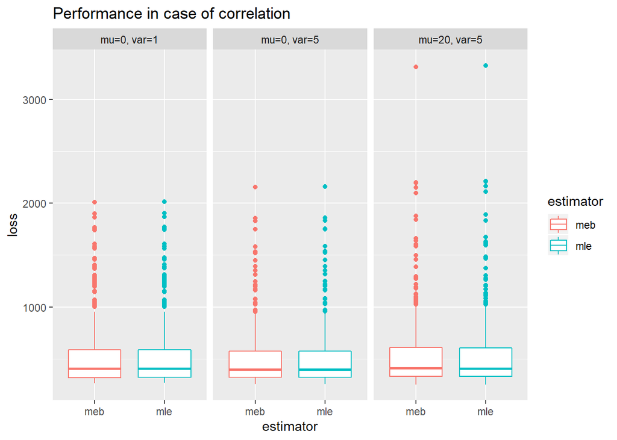

```
##     mu=0, var=1 mu=0, var=5 mu=20, var=5
## meb     510.384     497.777      523.915
## mle     511.392     498.762      524.058
```

## Assignment 3

Simulate $500$ realizations of the random vector $X=(X_1,...,X_p) \sim N(\mu, I)$ where $p=500$ and the vector $\mu$ is equal to:

1. $\mu_1=...=\mu_5=3.5$, $\mu_6=...=\mu_{500}=0$
2. $\mu_1=...=\mu_{30}=2.5$, $\mu_{31}=...=\mu_{500}=0$
3. $\mu_1=...=\mu_{100}=1.8$, $\mu_{101}=...=\mu_{500}=0$
4. $\mu_1=...=\mu_{500}=0.4$
5. $\mu_i=3.5i^{-\frac{1}{2}}$
6. $\mu_i=3.5i^{-1}$

For each of these examples compare the mean square error of the:

- maximum likelihood estimator
- James-Stein estimator
- hard-thresholding rule based on the Bonferroni correction with the nominal FWER equal to 0.1
- hard-thresholding rule based on the BH procedure with the nominal FDR equal to 0.1

First four parts of the exercise are constructed in a way that simulate transition from strong and sparse signals to weak and dense signals. In the last two parts vectors are dense and contain few strong signals.

### Estimation based on multiple testing procedures

The threshold for Bonferroni procedure is $\sqrt{2log500} \approx 3.535$, hence signals in all experiments are below required magnitude. It turns out that estimation based on Banjamini-Hochberg procedure and Bonferroni procedure have very similar performance in all cases, but Bonferroni procedure tends to perform better in scenarios 3-6. In experiments 1 and 2 the signals are sparse and relatively strong but still below Bonferroni optimal threshold. In such case Bonferroni procedure is not able to detect signals while Benjamini-Hochberg is able to do so. Even if BH makes more false discoveries, it is suppressed by the correct detections for significant $\mu$’s. In experiments 3 - 6, signals are so small that more conservative method starts to prevail.

### James-Stein estimator

James-Stein estimator seems to outperform other estimators when $||X||^2$ is large. Table below contains lengths of vector $X$ and values of shrinkage coefficient $\frac{p-2}{||X||^2}$ for a single vector $X \sim N(\mu_i, I)$.

```
##     Experiment    X_len Shrinkage
## 1 Experiment_1 515.0854    0.9668
## 2 Experiment_2 677.5965    0.7350
## 3 Experiment_3 779.4908    0.6389
## 4 Experiment_4 571.1927    0.8719
## 5 Experiment_5 600.9501    0.8287
## 6 Experiment_6 509.7206    0.9770
```

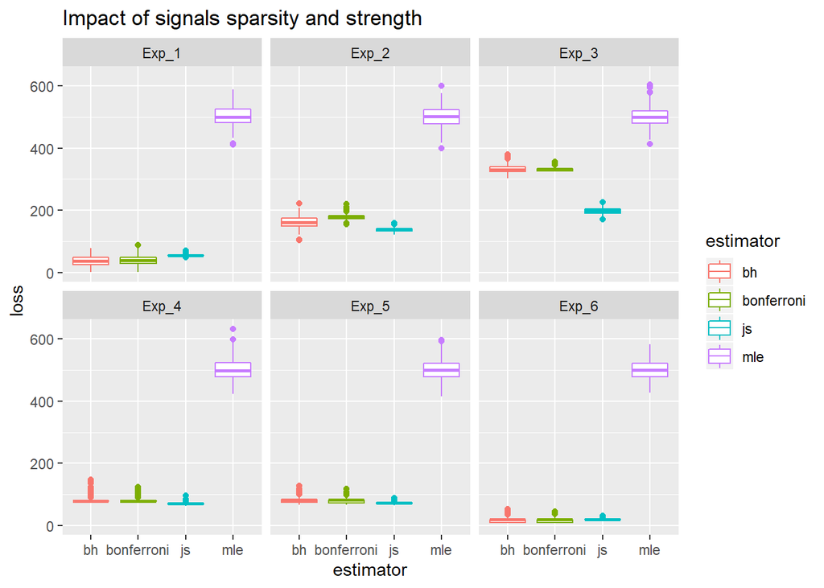

```
##              Exp_1   Exp_2   Exp_3   Exp_4   Exp_5   Exp_6
## bh          36.569 161.286 333.782  84.372  83.004  18.188
## bonferroni  40.855 178.409 331.457  83.488  80.905  17.420
## js          56.292 137.663 198.196  70.967  73.006  21.242
## mle        501.476 500.823 499.737 499.640 500.812 499.767
```